# Ionosphere data with tidymodels

Aymane Mimoun

2024-03-20

# Ionosphere data

Loading libraries we need in Machine Learning project.

```r
library(tidymodels)
library(tidyverse)
```

**Explanations about the data (`?Ionosphere`)**:

- This radar data was collected by a system in Goose Bay, Labrador. This system consists of a phased array of **16 high-frequency antennas** with a total transmitted power on the order of 6.4 kilowatts.
- The targets were free electrons in the ionosphere.
- **“good” radar** returns are those showing **evidence of some type of structure** in the ionosphere. **“bad” returns** are those that do not; their signals pass through the ionosphere.

We load the data and remove the empty second column (only zeros in this variable)

```r
library(mlbench)
data("Ionosphere")
iono <- as_tibble(Ionosphere[,-2])
iono$V1 <- as.double(iono$V1) - 1
```

We get a dataframe (a tibble) of dimensions

```r
iono %>% dim()
```

```
## [1] 351  34
```

# Exploratory data analysis

As a first step, we explore the structure of the dataset. We bear in mind a few possible goals:

- univariate analysis: distribution of the target variable (number of classes? imbalanced data?). Presence of missing data? Distribution of each variables (mean, dispersion…)
- bivariate analysis: Relationship between covariates or between a covariate and the target variable (correlation, prediction with simple univariate tools as simple logisitic regression…)
- multivariate analysis: dimensionality reduction PCA,([UMAP](https://umap-learn.readthedocs.io/en/latest/),…), data transformations (based on the meaning of each variable. Do we have to standardize or not? Change the units, create new variables…)

```r
iono %>% glimpse()
```

```
## Rows: 351
## Columns: 34
## $ V1    <dbl> 1, 1, 1, 1, 1, 1, 1, 0, 1, 1, 1, 1, 1, 1, 1, 1, 1, 0, 1, 0, 1, 0…
## $ V3    <dbl> 0.99539, 1.00000, 1.00000, 1.00000, 1.00000, 0.02337, 0.97588, 0…
## $ V4    <dbl> -0.05889, -0.18829, -0.03365, -0.45161, -0.02401, -0.00592, -0.1…
## $ V5    <dbl> 0.85243, 0.93035, 1.00000, 1.00000, 0.94140, -0.09924, 0.94601, …
## $ V6    <dbl> 0.02306, -0.36156, 0.00485, 1.00000, 0.06531, -0.11949, -0.20800…
## $ V7    <dbl> 0.83398, -0.10868, 1.00000, 0.71216, 0.92106, -0.00763, 0.92806,…
## $ V8    <dbl> -0.37708, -0.93597, -0.12062, -1.00000, -0.23255, -0.11824, -0.2…
## $ V9    <dbl> 1.00000, 1.00000, 0.88965, 0.00000, 0.77152, 0.14706, 0.85996, 0…
## $ V10   <dbl> 0.03760, -0.04549, 0.01198, 0.00000, -0.16399, 0.06637, -0.27342…
## $ V11   <dbl> 0.85243, 0.50874, 0.73082, 0.00000, 0.52798, 0.03786, 0.79766, -…
## $ V12   <dbl> -0.17755, -0.67743, 0.05346, 0.00000, -0.20275, -0.06302, -0.479…
## $ V13   <dbl> 0.59755, 0.34432, 0.85443, 0.00000, 0.56409, 0.00000, 0.78225, 0…
## $ V14   <dbl> -0.44945, -0.69707, 0.00827, 0.00000, -0.00712, 0.00000, -0.5076…
```

[output cut: 21 more lines]

```r
iono %>% summary()
```

```
##        V1               V3                V4                 V5
##  Min.   :0.0000   Min.   :-1.0000   Min.   :-1.00000   Min.   :-1.0000
##  1st Qu.:1.0000   1st Qu.: 0.4721   1st Qu.:-0.06474   1st Qu.: 0.4127
##  Median :1.0000   Median : 0.8711   Median : 0.01631   Median : 0.8092
##  Mean   :0.8917   Mean   : 0.6413   Mean   : 0.04437   Mean   : 0.6011
##  3rd Qu.:1.0000   3rd Qu.: 1.0000   3rd Qu.: 0.19418   3rd Qu.: 1.0000
##  Max.   :1.0000   Max.   : 1.0000   Max.   : 1.00000   Max.   : 1.0000
##        V6                V7                V8                 V9
##  Min.   :-1.0000   Min.   :-1.0000   Min.   :-1.00000   Min.   :-1.00000
##  1st Qu.:-0.0248   1st Qu.: 0.2113   1st Qu.:-0.05484   1st Qu.: 0.08711
##  Median : 0.0228   Median : 0.7287   Median : 0.01471   Median : 0.68421
##  Mean   : 0.1159   Mean   : 0.5501   Mean   : 0.11936   Mean   : 0.51185
##  3rd Qu.: 0.3347   3rd Qu.: 0.9692   3rd Qu.: 0.44567   3rd Qu.: 0.95324
##  Max.   : 1.0000   Max.   : 1.0000   Max.   : 1.00000   Max.   : 1.00000
##       V10                V11                V12                V13
##  Min.   :-1.00000   Min.   :-1.00000   Min.   :-1.00000   Min.   :-1.0000
##  1st Qu.:-0.04807   1st Qu.: 0.02112   1st Qu.:-0.06527   1st Qu.: 0.0000
##  Median : 0.01829   Median : 0.66798   Median : 0.02825   Median : 0.6441
##  Mean   : 0.18135   Mean   : 0.47618   Mean   : 0.15504   Mean   : 0.4008
##  3rd Qu.: 0.53419   3rd Qu.: 0.95790   3rd Qu.: 0.48237   3rd Qu.: 0.9555
##  Max.   : 1.00000   Max.   : 1.00000   Max.   : 1.00000   Max.   : 1.0000
##       V14                V15               V16                V17
##  Min.   :-1.00000   Min.   :-1.0000   Min.   :-1.00000   Min.   :-1.0000
##  1st Qu.:-0.07372   1st Qu.: 0.0000   1st Qu.:-0.08170   1st Qu.: 0.0000
##  Median : 0.03027   Median : 0.6019   Median : 0.00000   Median : 0.5909
##  Mean   : 0.09341   Mean   : 0.3442   Mean   : 0.07113   Mean   : 0.3819
##  3rd Qu.: 0.37486   3rd Qu.: 0.9193   3rd Qu.: 0.30897   3rd Qu.: 0.9357
##  Max.   : 1.00000   Max.   : 1.0000   Max.   : 1.00000   Max.   : 1.0000
##       V18                 V19               V20                V21
##  Min.   :-1.000000   Min.   :-1.0000   Min.   :-1.00000   Min.   :-1.0000
##  1st Qu.:-0.225690   1st Qu.: 0.0000   1st Qu.:-0.23467   1st Qu.: 0.0000
##  Median : 0.000000   Median : 0.5762   Median : 0.00000   Median : 0.4991
##  Mean   :-0.003617   Mean   : 0.3594   Mean   :-0.02402   Mean   : 0.3367
##  3rd Qu.: 0.195285   3rd Qu.: 0.8993   3rd Qu.: 0.13437   3rd Qu.: 0.8949
##  Max.   : 1.000000   Max.   : 1.0000   Max.   : 1.00000   Max.   : 1.0000
##       V22                 V23               V24                V25
##  Min.   :-1.000000   Min.   :-1.0000   Min.   :-1.00000   Min.   :-1.0000
##  1st Qu.:-0.243870   1st Qu.: 0.0000   1st Qu.:-0.36689   1st Qu.: 0.0000
##  Median : 0.000000   Median : 0.5318   Median : 0.00000   Median : 0.5539
##  Mean   : 0.008296   Mean   : 0.3625   Mean   :-0.05741   Mean   : 0.3961
```

[output cut: 8 more lines]

```
##  Max.   : 1.00000   Max.   : 1.0000   Max.   : 1.00000   Max.   : 1.0000
##       V30                V31               V32                 V33
##  Min.   :-1.00000   Min.   :-1.0000   Min.   :-1.000000   Min.   :-1.0000
##  1st Qu.:-0.23689   1st Qu.: 0.0000   1st Qu.:-0.242595   1st Qu.: 0.0000
##  Median : 0.00000   Median : 0.4428   Median : 0.000000   Median : 0.4096
##  Mean   :-0.02791   Mean   : 0.3525   Mean   :-0.003794   Mean   : 0.3494
##  3rd Qu.: 0.15407   3rd Qu.: 0.8576   3rd Qu.: 0.200120   3rd Qu.: 0.8138
##  Max.   : 1.00000   Max.   : 1.0000   Max.   : 1.000000   Max.   : 1.0000
##       V34            Class
##  Min.   :-1.00000   bad :126
##  1st Qu.:-0.16535   good:225
##  Median : 0.00000
##  Mean   : 0.01448
##  3rd Qu.: 0.17166
##  Max.   : 1.00000
```

Number of NA (missing data) ?

```r
iono %>% summarise_all(~sum(is.na(.))) %>% unlist()
```

```
##    V1    V3    V4    V5    V6    V7    V8    V9   V10   V11   V12   V13   V14
##     0     0     0     0     0     0     0     0     0     0     0     0     0
##   V15   V16   V17   V18   V19   V20   V21   V22   V23   V24   V25   V26   V27
##     0     0     0     0     0     0     0     0     0     0     0     0     0
##   V28   V29   V30   V31   V32   V33   V34 Class
##     0     0     0     0     0     0     0     0
```

**There is no missing data.**

### Univariate analysis

Boxplot for all variables together

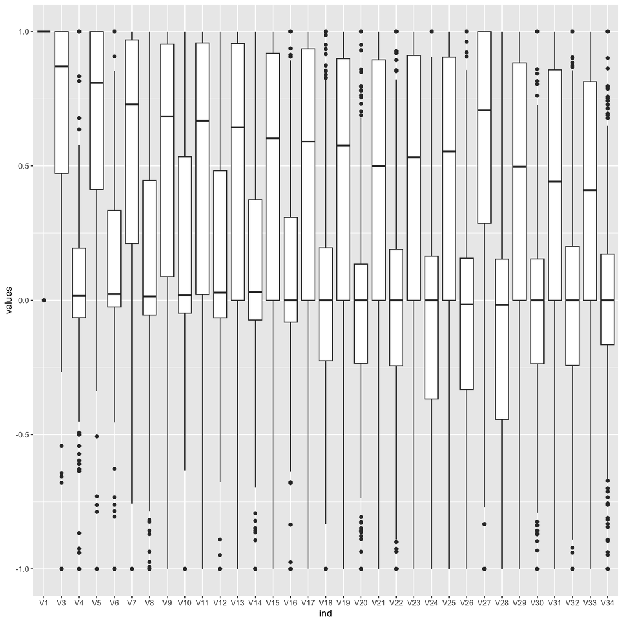

```r
iono %>% stack() %>% ggplot(aes(x = ind, y = values)) +
  geom_boxplot()
```

All the variables have **values between -1 and 1**. We observe **2 groups of data**: one with median values 0, another one with higher medians.

Verification

```r
iono %>% summarize(
    across(where(is.numeric), median)) %>% unlist()
```

```
##       V1       V3       V4       V5       V6       V7       V8       V9
##  1.00000  0.87111  0.01631  0.80920  0.02280  0.72873  0.01471  0.68421
##      V10      V11      V12      V13      V14      V15      V16      V17
##  0.01829  0.66798  0.02825  0.64407  0.03027  0.60194  0.00000  0.59091
##      V18      V19      V20      V21      V22      V23      V24      V25
##  0.00000  0.57619  0.00000  0.49909  0.00000  0.53176  0.00000  0.55389
##      V26      V27      V28      V29      V30      V31      V32      V33
## -0.01505  0.70824 -0.01769  0.49664  0.00000  0.44277  0.00000  0.40956
##      V34
##  0.00000
```

Some of the medians are equal to 0. Data were (surely) normalized to force a zero median value.

**The histograms**

Histograms of the group with “non-zero median”:

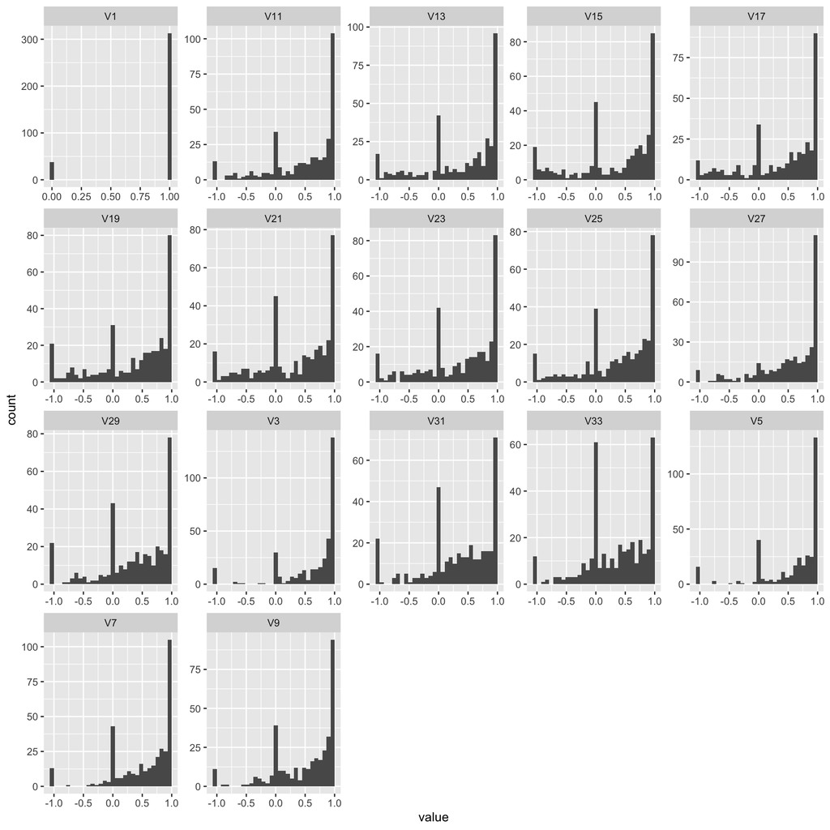

Histograms of the group with “zero median”:

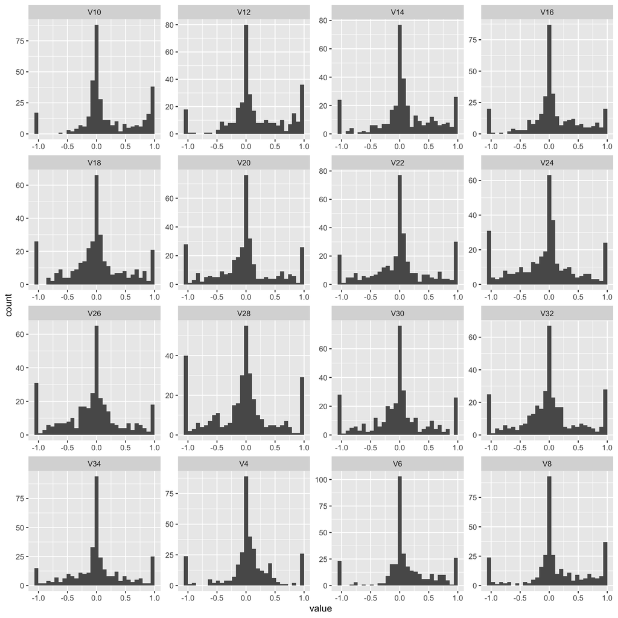

We observe a kind of saturation at -1 and 1 for most variables.

**Variable discrimination with respect to response variable `Class`?**

We plot again the boxplots but for the separate 2 groups AND the two responses “good” and “bad”.

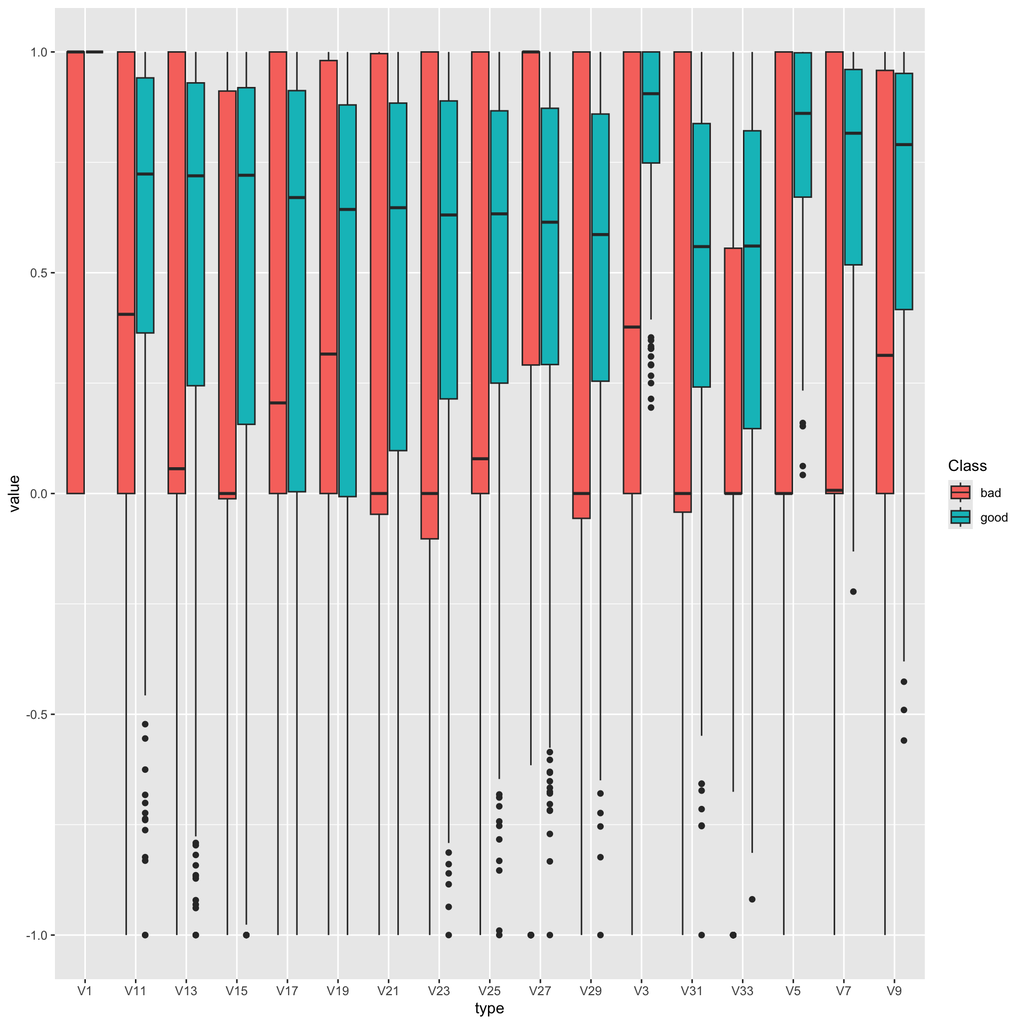

```r
iono %>% dplyr::select(all_of(c(g1,"Class"))) %>%
  gather(key = type, value = "value",1:length(g1)) %>%
  ggplot(aes(x = type, y=value, fill=Class)) +
    geom_boxplot()
```

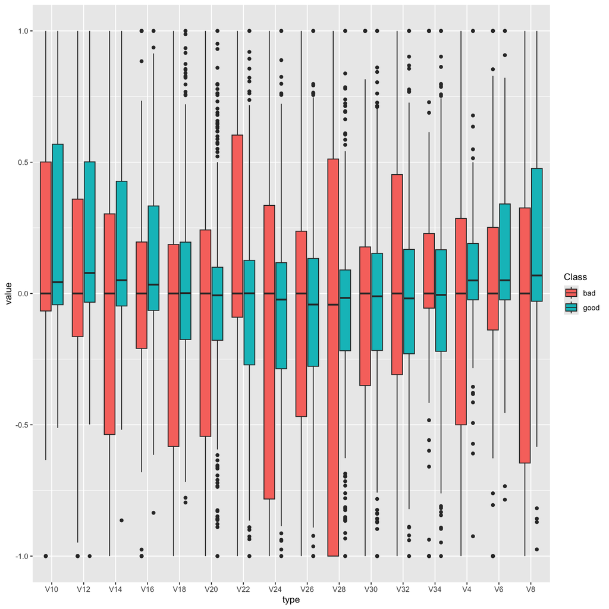

```r
iono %>% dplyr::select(all_of(c(g2,"Class"))) %>%
  gather(key = type, value = "value",1:length(g2)) %>%
  ggplot(aes(x = type, y=value, fill=Class)) +
    geom_boxplot()
```

**Comment:** For the “bad” observations, the variables have a greater dispersion (a higher variance) for most variables. The boxplots indicate that disciminating between observations with respect to the variable at hand seem a realistic objective.

### Bivariate analysis

We observe a strong correlation between the first variable and the Class

```r
t <- iono %>% dplyr::select(V1, Class) %>% table()
t
```

```
##    Class
## V1  bad good
##   0  38    0
##   1  88  225
```

Whenever $V1 = 0$ we are in class `bad`.

Using this unique variable, we can predict `bad` when `V1 = 0` and `good` when `V1 = 1`, the obtained accurary is:

```r
sum(diag(t))/sum(t)
```

```
## [1] 0.7492877
```

We plot the correlation matrix and highlight **5 groups of variables**. The first and the last groups contain all the “odd” variables (V3,V5,V7,…)

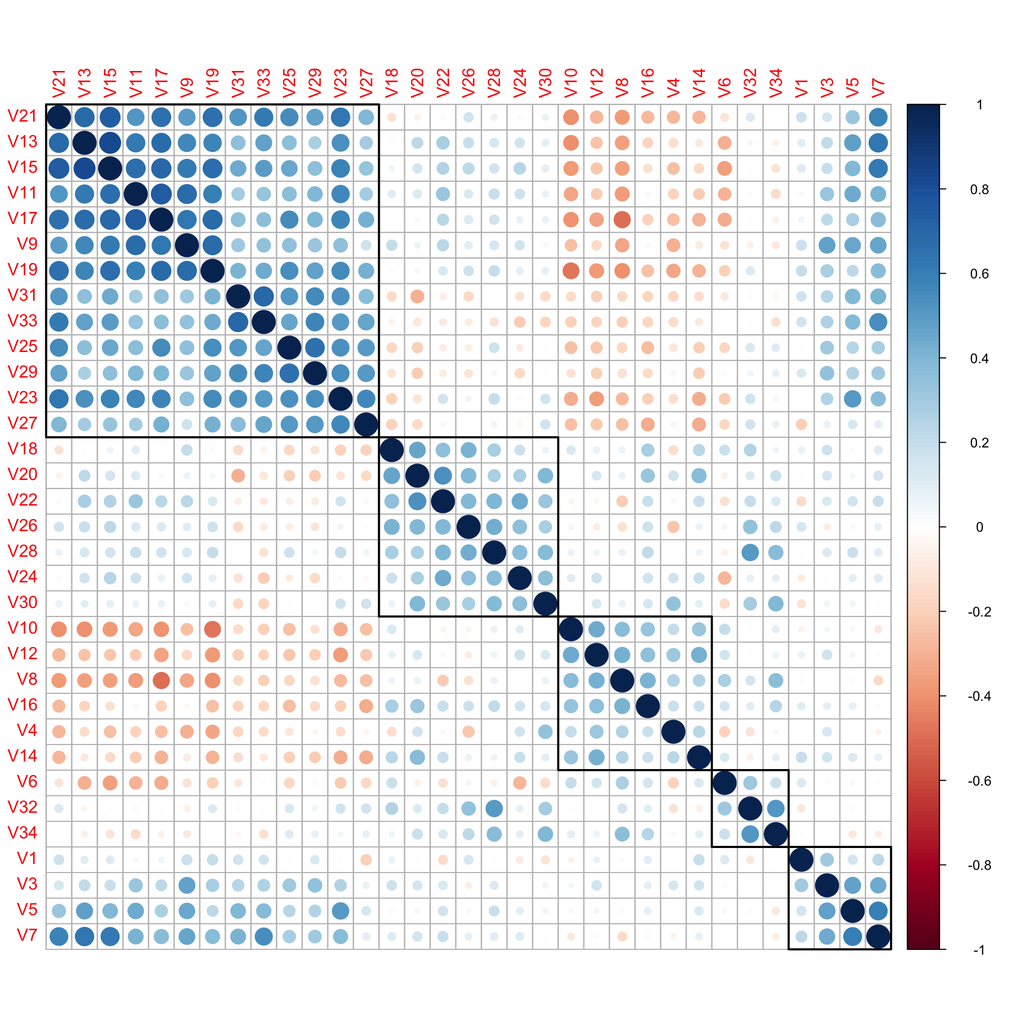

```r
library(corrplot)
cor.table <- iono %>%  select(-Class) %>% cor()
corrplot(cor.table, order = 'hclust', addrect = 5)
```

### Multivariate analysis: PCA

We close this exploratory analysis by a classic PCA. Our goal is to highlight a potential simpler structure within the data. The correlation structure (the previous plot) show that 5 groups and so, maybe, 5 principal components, could be a reasonable choice of dimensionnality reduction.

**This reduction or any other data transformation is performed in a second step only if the Machine Learning analysis in next sections give bad performances.** What means “bad performances” depend highly of the problem (the type of data, the state of the art…)

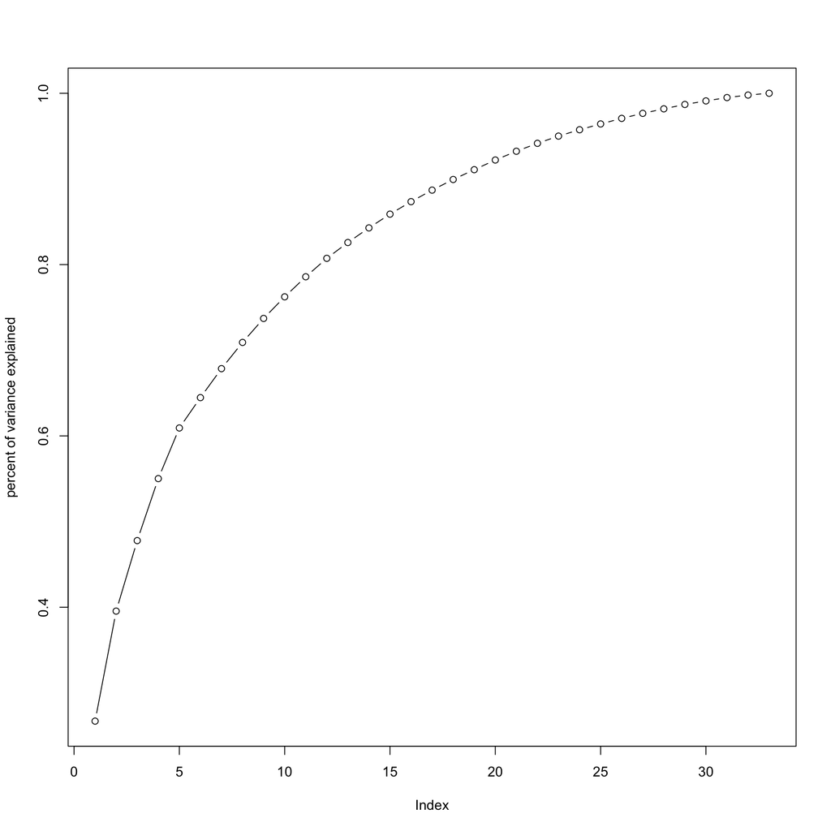

```r
rec <- recipe(Class ~ ., data = iono) %>%
  step_normalize(all_predictors()) %>%
  step_pca(all_predictors())
prep <- prep(rec)
var_prop <- summary(prep$steps[[2]]$res)
plot(cumsum(var_prop$importance[2,]), type = 'b', ylab = "percent of variance explained")
```

We explain about 60% of the data variance with 5 components. We need 12 components to explain 80% of the variables.

```r
cumsum(var_prop$importance[2,])[5]
```

```
##     PC5
## 0.60926
```

```r
which(cumsum(var_prop$importance[2,]) > 0.8)[1]
```

```
## PC12
##   12
```

**Comments:** The reduction with PCA is not an absurd idea: we can remove almost 2/3 of the data and still explain 80% of the data variance. This result is corroborated by the apparent grouping obtained in the correlation plot.

# Logistic Regression

We start by recalling the percent of data in each of the 2 classes (bad and good)

```r
prop <- iono %>% select(Class) %>% table()
prop
```

```
## Class
##  bad good
##  126  225
```

```r
prop/sum(prop)*100
```

```
## Class
##      bad     good
## 35.89744 64.10256
```

We don’t have imbalanced data. The first very simple model (seen in previous section) using only the binary variable `V1` to predict the `Class` have accuracy of:

```r
sum(diag(t))/sum(t)
```

```
## [1] 0.7492877
```

**In this section, we will test a first algorithm, the logistic regression, in order to try improving this 75% accuracy performance.**

## The standard “one-step” logisitic regression

In `tidymodels` package, we use:

- data with `recipe`
- method for cross validation in `vfold_cv`
- metrics in `metric_set`
- machine learning method with `set_engine`.

```r
recipe <- iono %>% recipe(Class ~ .)
folds <- iono %>% vfold_cv(v = 4, strata = Class)
my_metrics <- metric_set(accuracy, roc_auc)
lr <- logistic_reg(mode = "classification") %>% set_engine("glm")
```

We run the algorithm and collect the result

```r
logistic_cv <- fit_resamples(object = lr,
                             preprocessor = recipe,
                             resamples = folds,
                             metrics = my_metrics,
                             control = control_resamples(save_pred = TRUE))
```

```
## → A | warning: glm.fit: fitted probabilities numerically 0 or 1 occurred
```

[output not shown]

```r
res_log <- logistic_cv %>% collect_metrics()
```

```r
res_log$mean[1]
```

```
## [1] 0.8658176
```

**Comment: We obtain an improved result with an accuracy of about 85%.**

```r
logistic_cv %>% conf_mat_resampled(tidy = FALSE)
```

```
##        bad  good
## bad  24.00  4.25
## good  7.50 52.00
```

## Remark about train-test data

What if we run the algorithm on the data we used to learn the classifier?

```r
Class.predicted <-  lr %>% fit(Class ~ ., data = iono) %>% predict(iono)
t <- Class.predicted %>% unlist() %>% table(iono$Class)
t
```

```
##
## .      bad good
##   bad  111    7
##   good  15  218
```

```r
sum(diag(t))/sum(t)
```

```
## [1] 0.9373219
```

**we get too good performances, which does no reflect the reality of the performance.**

## ROC curve

On example code proposed here: https://stateofther.github.io/finistR2019/s-tidymodels.html

We reproduce the code used in this example with our dataset.

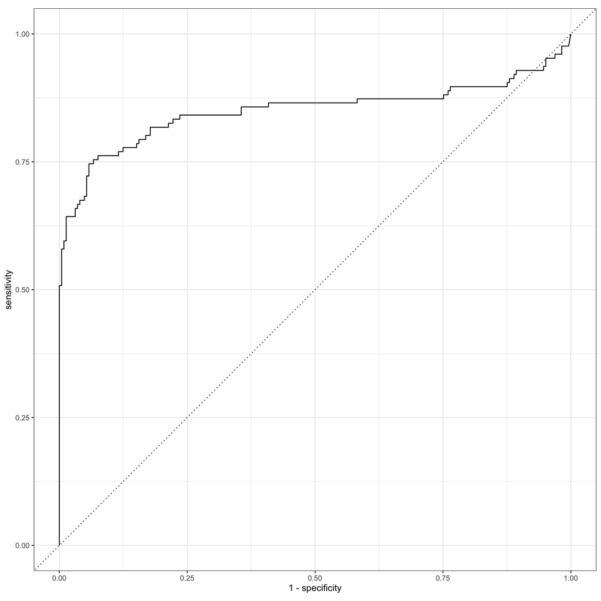

```r
auc <- augment(logistic_cv) %>%
  roc_curve(Class, .pred_bad)
auc %>% autoplot()
```

The best model is obtained for the following threshold

```r
ind <- which.max(auc$specificity + auc$sensitivity)
auc[ind,]
```

```
## # A tibble: 1 × 3
##   .threshold specificity sensitivity
##        <dbl>       <dbl>       <dbl>
## 1      0.800       0.942       0.746
```

And its asssociated accuracy is

```r
prev <- sum(iono$Class == "good")/nrow(iono)
(auc[ind,2]*prev + auc[ind,3]*(1-prev)) %>% unlist() %>% unname()
```

```
## [1] 0.8717949
```

```r
res_REG <- (auc[ind,2]*prev + auc[ind,3]*(1-prev)) %>% unlist() %>% unname()
cat("accurary REG = ", res_REG)
```

```
## accurary REG =  0.8717949
```

**Comment: Compared to the first result (with no optimal threshold) it’s a very small improvment.**

# Naive Bayes

## Data preparation

Here we split the data in train and test. We perform cross-validation on the train dataset for tuning parameters.

We use the same TRAINT/TEST/CV data for all the following algorithms.

Here `smoothness` and `Laplace` are tuning parameters.

```r
SPLIT <- iono %>% initial_split(prop = 0.70)
TRAIN <- SPLIT %>% training()
TEST  <- SPLIT %>% testing()
CV <- TRAIN %>% vfold_cv(v = 5)

# data transformation / data preparation for the algo
model_recipe <- TRAIN %>% recipe(Class ~ .)
```

## Workflow definition

```r
library(discrim)
nb_model <-
  naive_Bayes(mode = "classification",
              smoothness = tune(),
              Laplace = tune(),
              engine = "naivebayes"
  )

nb_wf <-
  workflow() %>%
  add_model(nb_model) %>%
  add_recipe(model_recipe)
nb_wf
```

```
## ══ Workflow ════════════════════════════════════════════════════════════════════
## Preprocessor: Recipe
## Model: naive_Bayes()
##
## ── Preprocessor ────────────────────────────────────────────────────────────────
## 0 Recipe Steps
##
## ── Model ───────────────────────────────────────────────────────────────────────
## Naive Bayes Model Specification (classification)
##
## Main Arguments:
##   smoothness = tune()
##   Laplace = tune()
##
## Computational engine: naivebayes
```

## Hyperparameter Tuning

We test different values for hyperparameters in CV.

```r
nb_results <- nb_wf %>%
                  tune_grid(resamples = CV,
                  metrics = metric_set(accuracy))

nb_results %>% collect_metrics()
```

```
## # A tibble: 10 × 8
##    smoothness Laplace .metric  .estimator  mean     n std_err .config
##         <dbl>   <dbl> <chr>    <chr>      <dbl> <int>   <dbl> <chr>
##  1      1.06   0.320  accuracy binary     0.898     5  0.0214 Preprocessor1_Mod…
##  2      1.34   1.30   accuracy binary     0.906     5  0.0178 Preprocessor1_Mod…
##  3      1.45   0.824  accuracy binary     0.910     5  0.0189 Preprocessor1_Mod…
##  4      1.16   0.0295 accuracy binary     0.902     5  0.0176 Preprocessor1_Mod…
##  5      0.891  2.96   accuracy binary     0.894     5  0.0198 Preprocessor1_Mod…
##  6      1.25   1.51   accuracy binary     0.906     5  0.0178 Preprocessor1_Mod…
##  7      0.675  2.52   accuracy binary     0.902     5  0.0176 Preprocessor1_Mod…
##  8      0.729  2.03   accuracy binary     0.902     5  0.0176 Preprocessor1_Mod…
##  9      0.513  1.06   accuracy binary     0.902     5  0.0176 Preprocessor1_Mod…
## 10      0.948  2.19   accuracy binary     0.894     5  0.0198 Preprocessor1_Mod…
```

We return the best model

```r
param_final <- nb_results %>%
  select_best(metric = "accuracy")

nb_wf <- nb_wf %>%
  finalize_workflow(param_final)
nb_wf
```

```
## ══ Workflow ════════════════════════════════════════════════════════════════════
## Preprocessor: Recipe
## Model: naive_Bayes()
##
## ── Preprocessor ────────────────────────────────────────────────────────────────
## 0 Recipe Steps
##
## ── Model ───────────────────────────────────────────────────────────────────────
## Naive Bayes Model Specification (classification)
##
## Main Arguments:
##   smoothness = 1.44984219460748
##   Laplace = 0.823698443477042
##
## Computational engine: naivebayes
```

## Apply to test data

Function `last_fit` evaluation the model on testing data.

```r
# Last Fit
nb_fit <- nb_wf %>% last_fit(SPLIT)

test_performance <- nb_fit %>% collect_predictions()
test_performance
```

```
## # A tibble: 106 × 7
##    .pred_class .pred_bad .pred_good id                .row Class .config
##    <fct>           <dbl>      <dbl> <chr>            <int> <fct> <chr>
##  1 good         6.95e-10   1.00e+ 0 train/test split     3 good  Preprocessor1_…
##  2 bad          1.00e+ 0   3.13e- 4 train/test split    10 bad   Preprocessor1_…
##  3 bad          1.00e+ 0   2.88e- 4 train/test split    12 bad   Preprocessor1_…
##  4 good         3.82e- 3   9.96e- 1 train/test split    14 bad   Preprocessor1_…
##  5 good         8.63e- 3   9.91e- 1 train/test split    27 good  Preprocessor1_…
##  6 bad          1   e+ 0   3.71e-16 train/test split    28 bad   Preprocessor1_…
##  7 good         2.46e- 3   9.98e- 1 train/test split    29 good  Preprocessor1_…
##  8 good         4.60e- 9   1.00e+ 0 train/test split    31 good  Preprocessor1_…
##  9 bad          1.00e+ 0   8.15e-11 train/test split    32 bad   Preprocessor1_…
## 10 good         2.74e- 9   1.00e+ 0 train/test split    39 good  Preprocessor1_…
## # ℹ 96 more rows
```

```r
# Performance Metrics
diabetes_metrics <- metric_set(accuracy, f_meas, precision, recall)
diabetes_metrics(data = test_performance, truth = Class, estimate = .pred_class)
```

```
## # A tibble: 4 × 3
##   .metric   .estimator .estimate
##   <chr>     <chr>          <dbl>
## 1 accuracy  binary         0.925
## 2 f_meas    binary         0.882
## 3 precision binary         0.938
## 4 recall    binary         0.833
```

```r
# Confusion Matrix
conf_mat(test_performance, Class, .pred_class)
```

```
##           Truth
## Prediction bad good
##       bad   30    2
##       good   6   68
```

**Comment: obained accuracy of about 90%**

```r
res_NB <- diabetes_metrics(data = test_performance, truth = Class, estimate = .pred_class)
res_NB <- res_NB$.estimate[1]
cat("accurary NB = ", res_NB)
```

```
## accurary NB =  0.9245283
```

# LDA

We repeat the same strategy with LDA model

```r
library(discrim)

nb_model <-
discrim_linear() %>%
  set_mode("classification") %>%
  set_engine("MASS")

nb_wf <-
  workflow() %>%
  add_model(nb_model) %>%
  add_recipe(model_recipe)

nb_results <- nb_wf %>%
                  tune_grid(resamples = CV,
                  metrics = metric_set(accuracy))
nb_results %>% collect_metrics()
```

```
## # A tibble: 1 × 6
##   .metric  .estimator  mean     n std_err .config
##   <chr>    <chr>      <dbl> <int>   <dbl> <chr>
## 1 accuracy binary     0.845     5  0.0278 Preprocessor1_Model1
```

```r
param_final <- nb_results %>%
  select_best(metric = "accuracy")

nb_wf <- nb_wf %>%
  finalize_workflow(param_final)

# Last Fit
nb_fit <- nb_wf %>% last_fit(SPLIT)

test_performance <- nb_fit %>% collect_predictions()
test_performance
```

```
## # A tibble: 106 × 7
##    .pred_class .pred_bad .pred_good id                .row Class .config
##    <fct>           <dbl>      <dbl> <chr>            <int> <fct> <chr>
##  1 good          0.00359    0.996   train/test split     3 good  Preprocessor1_…
##  2 bad           0.993      0.00666 train/test split    10 bad   Preprocessor1_…
##  3 good          0.0343     0.966   train/test split    12 bad   Preprocessor1_…
##  4 good          0.0212     0.979   train/test split    14 bad   Preprocessor1_…
##  5 good          0.0499     0.950   train/test split    27 good  Preprocessor1_…
##  6 bad           0.995      0.00512 train/test split    28 bad   Preprocessor1_…
##  7 good          0.00248    0.998   train/test split    29 good  Preprocessor1_…
##  8 good          0.00368    0.996   train/test split    31 good  Preprocessor1_…
##  9 bad           0.990      0.00956 train/test split    32 bad   Preprocessor1_…
## 10 good          0.00369    0.996   train/test split    39 good  Preprocessor1_…
## # ℹ 96 more rows
```

```r
# Performance Metrics
diabetes_metrics <- metric_set(accuracy, f_meas, precision, recall)
diabetes_metrics(data = test_performance, truth = Class, estimate = .pred_class)
```

```
## # A tibble: 4 × 3
##   .metric   .estimator .estimate
##   <chr>     <chr>          <dbl>
## 1 accuracy  binary         0.887
## 2 f_meas    binary         0.8
## 3 precision binary         1
## 4 recall    binary         0.667
```

```r
# Confusion Matrix
conf_mat(test_performance, Class, .pred_class)
```

```
##           Truth
## Prediction bad good
##       bad   24    0
##       good  12   70
```

```r
res_LDA <- diabetes_metrics(data = test_performance, truth = Class, estimate = .pred_class)
res_LDA <- res_LDA$.estimate[1]
cat("accurary LDA = ", res_LDA)
```

```
## accurary LDA =  0.8867925
```

# KNN

## Preparation of the workflow

```r
tune_spec <- nearest_neighbor(neighbors=tune(), weight_func="rectangular") %>%
                set_mode("classification") %>%
                set_engine("kknn")
```

workflow: our target is variable “Class” (with this data)

```r
ppv_wf <- workflow() %>%
            add_model(tune_spec) %>%
            add_formula(Class ~ .)
```

```r
grille_k <- tibble(neighbors=1:20)
```

## Running the algorithm

for each value of k - knn algo 5 times (cv) - each time evalute accuracy - mean of the accuracy

```r
ppv.cv <- ppv_wf %>%
  tune_grid(
    resamples = CV,
    grid = grille_k,
    metrics=metric_set(accuracy))
```

Analysis of the Result

```r
ppv.cv %>% collect_metrics()
```

```
## # A tibble: 20 × 7
##    neighbors .metric  .estimator  mean     n std_err .config
##        <int> <chr>    <chr>      <dbl> <int>   <dbl> <chr>
##  1         1 accuracy binary     0.837     5  0.0365 Preprocessor1_Model01
##  2         2 accuracy binary     0.837     5  0.0365 Preprocessor1_Model02
##  3         3 accuracy binary     0.824     5  0.0320 Preprocessor1_Model03
##  4         4 accuracy binary     0.824     5  0.0320 Preprocessor1_Model04
##  5         5 accuracy binary     0.820     5  0.0332 Preprocessor1_Model05
##  6         6 accuracy binary     0.820     5  0.0332 Preprocessor1_Model06
##  7         7 accuracy binary     0.812     5  0.0405 Preprocessor1_Model07
##  8         8 accuracy binary     0.812     5  0.0405 Preprocessor1_Model08
##  9         9 accuracy binary     0.812     5  0.0356 Preprocessor1_Model09
## 10        10 accuracy binary     0.812     5  0.0356 Preprocessor1_Model10
## 11        11 accuracy binary     0.804     5  0.0333 Preprocessor1_Model11
## 12        12 accuracy binary     0.804     5  0.0333 Preprocessor1_Model12
## 13        13 accuracy binary     0.796     5  0.0323 Preprocessor1_Model13
## 14        14 accuracy binary     0.796     5  0.0323 Preprocessor1_Model14
## 15        15 accuracy binary     0.796     5  0.0323 Preprocessor1_Model15
## 16        16 accuracy binary     0.796     5  0.0323 Preprocessor1_Model16
## 17        17 accuracy binary     0.792     5  0.0269 Preprocessor1_Model17
## 18        18 accuracy binary     0.792     5  0.0269 Preprocessor1_Model18
## 19        19 accuracy binary     0.788     5  0.0263 Preprocessor1_Model19
## 20        20 accuracy binary     0.788     5  0.0263 Preprocessor1_Model20
```

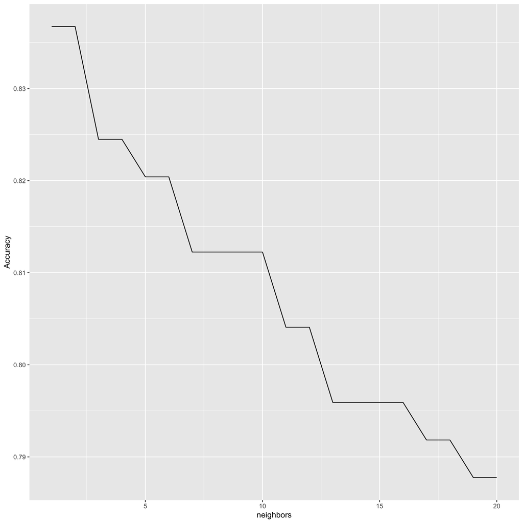

```r
tbl <- ppv.cv %>% collect_metrics()

ggplot(tbl) +
  aes(x = neighbors,y = mean) +
  geom_line() +
  ylab("Accuracy")
```

## Building the best model

= !!! production !!!

```r
best_k <- ppv.cv %>% select_best()
best_k
```

```
## # A tibble: 1 × 2
##   neighbors .config
##       <int> <chr>
## 1         1 Preprocessor1_Model01
```

```r
final_ppv <-
   ppv_wf %>%
   finalize_workflow(best_k) %>%
   fit(data = TRAIN)


########################################################
### all predictions
res <- predict(final_ppv, new_data = TEST)
mean(TEST$Class == res$.pred_class)
```

```
## [1] 0.8773585
```

```r
res_KNN <- mean(TEST$Class == res$.pred_class)
cat("accurary KNN = ", res_KNN)
```

```
## accurary KNN =  0.8773585
```

**The best model is here the 1-KNN with 1 neighbor. This is maybe the sign that this algorithm is not a good strategy. The data are not well separated.**

# SVM

with radial basis kernel function.

```r
nb_model <-
  svm_rbf(cost = tune(), rbf_sigma = tune()) %>%
  set_mode("classification") %>%
  set_engine("kernlab")

nb_wf <-
  workflow() %>%
  add_model(nb_model) %>%
  add_recipe(model_recipe)

nb_results <- nb_wf %>%
                  tune_grid(resamples = CV,
                  metrics = metric_set(accuracy))

nb_results %>% collect_metrics()
```

```
## # A tibble: 10 × 8
##        cost rbf_sigma .metric  .estimator  mean     n std_err .config
##       <dbl>     <dbl> <chr>    <chr>      <dbl> <int>   <dbl> <chr>
##  1  0.00117  8.51e- 9 accuracy binary     0.633     5  0.0393 Preprocessor1_Mod…
##  2  0.147    7.11e- 1 accuracy binary     0.633     5  0.0393 Preprocessor1_Mod…
##  3  0.00480  1.26e- 8 accuracy binary     0.633     5  0.0393 Preprocessor1_Mod…
##  4  3.32     5.85e- 7 accuracy binary     0.633     5  0.0393 Preprocessor1_Mod…
##  5  0.348    4.03e-10 accuracy binary     0.633     5  0.0393 Preprocessor1_Mod…
##  6 26.9      1.19e- 6 accuracy binary     0.633     5  0.0393 Preprocessor1_Mod…
##  7  0.629    1.57e- 2 accuracy binary     0.927     5  0.0220 Preprocessor1_Mod…
##  8 10.8      4.91e- 3 accuracy binary     0.931     5  0.0153 Preprocessor1_Mod…
##  9  0.0293   1.57e- 4 accuracy binary     0.633     5  0.0393 Preprocessor1_Mod…
## 10  0.0133   1.67e- 5 accuracy binary     0.633     5  0.0393 Preprocessor1_Mod…
```

```r
param_final <- nb_results %>%
  select_best(metric = "accuracy")

nb_wf <- nb_wf %>%
  finalize_workflow(param_final)

# Last Fit
nb_fit <- nb_wf %>% last_fit(SPLIT)

test_performance <- nb_fit %>% collect_predictions()
test_performance
```

```
## # A tibble: 106 × 7
##    .pred_class .pred_bad .pred_good id                .row Class .config
##    <fct>           <dbl>      <dbl> <chr>            <int> <fct> <chr>
##  1 good           0.0167   0.983    train/test split     3 good  Preprocessor1_…
##  2 bad            0.974    0.0259   train/test split    10 bad   Preprocessor1_…
##  3 bad            0.963    0.0369   train/test split    12 bad   Preprocessor1_…
##  4 good           0.444    0.556    train/test split    14 bad   Preprocessor1_…
##  5 good           0.156    0.844    train/test split    27 good  Preprocessor1_…
##  6 bad            1.00     0.000168 train/test split    28 bad   Preprocessor1_…
##  7 good           0.121    0.879    train/test split    29 good  Preprocessor1_…
##  8 good           0.0810   0.919    train/test split    31 good  Preprocessor1_…
##  9 bad            0.996    0.00374  train/test split    32 bad   Preprocessor1_…
## 10 good           0.0328   0.967    train/test split    39 good  Preprocessor1_…
## # ℹ 96 more rows
```

```r
# Performance Metrics
diabetes_metrics <- metric_set(accuracy, f_meas, precision, recall)
diabetes_metrics(data = test_performance, truth = Class, estimate = .pred_class)
```

```
## # A tibble: 4 × 3
##   .metric   .estimator .estimate
##   <chr>     <chr>          <dbl>
## 1 accuracy  binary         0.953
## 2 f_meas    binary         0.925
## 3 precision binary         1
## 4 recall    binary         0.861
```

```r
# Confusion Matrix
conf_mat(test_performance, Class, .pred_class)
```

```
##           Truth
## Prediction bad good
##       bad   31    0
##       good   5   70
```

```r
res_SVM <- diabetes_metrics(data = test_performance, truth = Class, estimate = .pred_class)
res_SVM <- res_SVM$.estimate[1]
cat("accurary SVM = ", res_SVM)
```

```
## accurary SVM =  0.9528302
```

# Conclusion

We repeat all our results:

```
## accurary REG =  0.8717949
```

```
## accurary NB =  0.9245283
```

```
## accurary LDA =  0.8867925
```

```
## accurary KNN =  0.8773585
```

```
## accurary SVM =  0.9528302
```

and search for the best one with the highest accuracy.

```r
all_res <- c(res_REG, res_NB, res_LDA, res_KNN, res_SVM)
order(all_res, decreasing = TRUE)
```

```
## [1] 5 2 3 4 1
```

```r
which.max(all_res)
```

```
## [1] 5
```

- **The best method is the SVM (with radial basis kernel function) with an accuracy close to 95%**
- Notice that the dataset used for this machine learning is of small size. Only 351 observations. When repeating the analysis, the SVM returns sometimes bad accuracy performances.
- Naive Bayes Algorithm is more robust.
- We need more data to confirm our results.

We run again the SVM algo but on the PCA data with 12 components (80% of the variance explained).

```
## accurary SVM =  0.9056604
```

The result is not improved.